# Predicting Medical Charges with R Regression

Voy Adamek

2023-03-15

### **Introduction**

In this project, we will explore a dataset of medical insurance charges and use linear regression to predict the charges based on various factors such as age, sex, BMI, smoker status, and region. We will also visualize the data to gain insights and better understand the relationships between the different variables.

### **Loading the data**

First, we need to load the insurance dataset and check its contents. We use the `read.csv()` function to load the data into a dataframe and the `plot()` function to create a scatter plot of all the numeric columns in the dataframe.

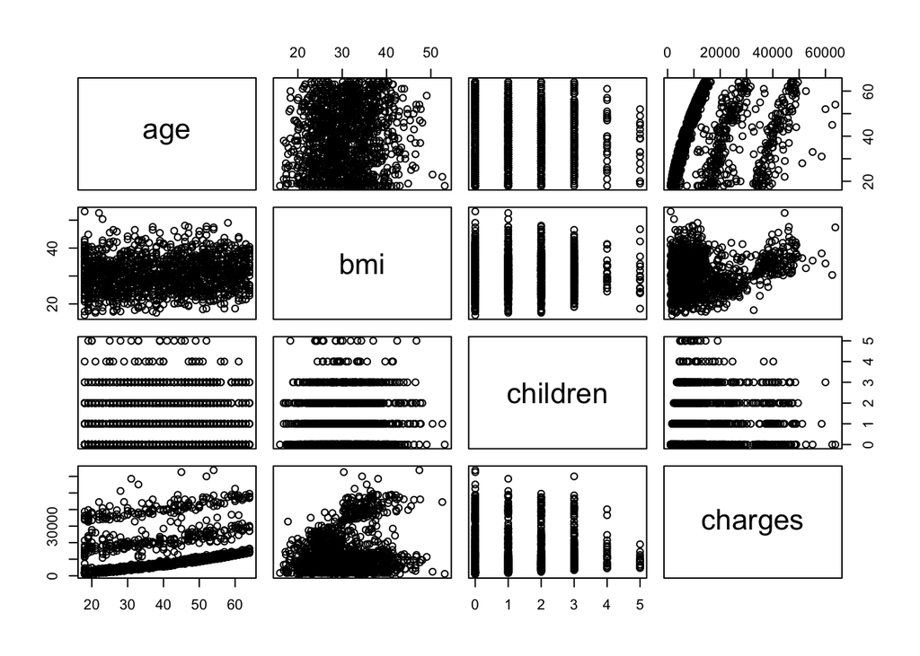

```r
df = read.csv('insurance.csv', header=TRUE)
num_cols <- unlist(lapply(df, is.numeric))
plot(df[,num_cols])
```

We can see from the plot that there is some correlation between the variables, but it’s not immediately clear which variables are the most important. To get a better idea of the correlations, we can use the cor() function to create a correlation matrix.

```r
round(cor(df[,num_cols]),2)
```

```
##           age  bmi children charges
## age      1.00 0.11     0.04    0.30
## bmi      0.11 1.00     0.01    0.20
## children 0.04 0.01     1.00    0.07
## charges  0.30 0.20     0.07    1.00
```